# Exploratory Data Analysis

## Explore the *CustomerData* Dataset with R

### 1.Load Data

```r
setwd("G:/UCinn Course Work/Sem2/Data Mining1/Data Exploration Using R")
CustomerData<-read.csv("CustomerData.csv",header=TRUE,sep=",")
```

### 1.1Take a look into the data

```r
head(CustomerData)
```

|  | CustomerID | Region | TownSize | Gender | Age | EducationYears | JobCategory | UnionMember | EmploymentLength | Retired | HHIncome | DebtToIncomeRatio | CreditDebt | OtherDebt | LoanDefault | MaritalStatus | HouseholdSize | NumberPets | NumberCats | NumberDogs | NumberBirds | HomeOwner | CarsOwned | CarOwnership | CarBrand | CarValue | CommuteTime | PoliticalPartyMem | Votes | … |
| --- | --- | --- | --- | --- | --- | --- | --- | --- | --- | --- | --- | --- | --- | --- | --- | --- | --- | --- | --- | --- | --- | --- | --- | --- | --- | --- | --- | --- | --- | --- |
| 1 | 3964-QJWTRG-NPN | 1 | 2 | Female | 20 | 15 | Professional | Yes | 0 | No | 31000 | 11.1 | 1.200909 | 2.240091 | Yes | Unmarried | 3 | 0 | 0 | 0 | 0 | 0 | 2 | Own | Domestic | 14300 | 22 | Yes | Yes | … |
| 2 | 0648-AIPJSP-UVM | 5 | 5 | Male | 22 | 17 | Sales | No | 0 | No | 15000 | 18.6 | 1.222020 | 1.567980 | Yes | Unmarried | 2 | 6 | 0 | 0 | 0 | 1 | 2 | Own | Foreign | 6800 | 29 | Yes | No | … |
| 3 | 5195-TLUDJE-HVO | 3 | 4 | Female | 67 | 14 | Sales | No | 16 | No | 35000 | 9.9 | 0.928620 | 2.536380 | No | Married | 3 | 3 | 2 | 1 | 0 | 1 | 3 | Own | Foreign | 18800 | 24 | Yes | No | … |
| 4 | 4459-VLPQUH-3OL | 4 | 3 | Male | 23 | 16 | Sales | No | 0 | No | 20000 | 5.7 | 0.022800 | 1.117200 | Yes | Married | 5 | 0 | 0 | 0 | 0 | 1 | 3 | Own | Foreign | 8700 | 38 | No | No | … |
| 5 | 8158-SMTQFB-CNO | 2 | 2 | Male | 26 | 16 | Sales | No | 1 | No | 23000 | 1.7 | 0.214659 | 0.176341 | No | Married | 4 | 0 | 0 | 0 | 0 | 0 | 1 | Lease | Foreign | 10600 | 32 | No | No | … |
| 6 | 9662-FUSYIM-1IV | 4 | 4 | Male | 64 | 17 | Service | No | 22 | No | 107000 | 5.6 | 1.060584 | 4.931416 | No | Unmarried | 1 | 11 | 1 | 1 | 0 | 1 | 0 | -1 | -1 | -1000 | 23 | No | No | … |

### 1.2 Size of the dataset

### 1.2.1 How larger is my dataset? How many rows? How many columns?

```r
dim(CustomerData)
```

```
## [1] 5000   59
```

### 1.2.2 How many columns?

```r
ncol(CustomerData)
```

```
## [1] 59
```

# 1.2.3 How many rows?

```r
nrow(CustomerData)
```

```
## [1] 5000
```

# 1.3 Glimpse at the variables

# 1.3.1 What is the name of my columns?

```r
names(CustomerData)
```

```
##  [1] "CustomerID"          "Region"              "TownSize"
##  [4] "Gender"              "Age"                 "EducationYears"
##  [7] "JobCategory"         "UnionMember"         "EmploymentLength"
## [10] "Retired"             "HHIncome"            "DebtToIncomeRatio"
## [13] "CreditDebt"          "OtherDebt"           "LoanDefault"
## [16] "MaritalStatus"       "HouseholdSize"       "NumberPets"
## [19] "NumberCats"          "NumberDogs"          "NumberBirds"
## [22] "HomeOwner"           "CarsOwned"           "CarOwnership"
## [25] "CarBrand"            "CarValue"            "CommuteTime"
## [28] "PoliticalPartyMem"   "Votes"               "CreditCard"
## [31] "CardTenure"          "CardItemsMonthly"    "CardSpendMonth"
## [34] "ActiveLifestyle"     "PhoneCoTenure"       "VoiceLastMonth"
## [37] "VoiceOverTenure"     "EquipmentRental"     "EquipmentLastMonth"
## [40] "EquipmentOverTenure" "CallingCard"         "WirelessData"
## [43] "DataLastMonth"       "DataOverTenure"      "Multiline"
## [46] "VM"                  "Pager"               "Internet"
## [49] "CallerID"            "CallWait"            "CallForward"
## [52] "ThreeWayCalling"     "EBilling"            "TVWatchingHours"
## [55] "OwnsPC"              "OwnsMobileDevice"    "OwnsGameSystem"
## [58] "OwnsFax"             "NewsSubscriber"
```

```r
#OR

colnames(CustomerData)
```

```
##  [1] "CustomerID"          "Region"              "TownSize"
##  [4] "Gender"              "Age"                 "EducationYears"
##  [7] "JobCategory"         "UnionMember"         "EmploymentLength"
## [10] "Retired"             "HHIncome"            "DebtToIncomeRatio"
## [13] "CreditDebt"          "OtherDebt"           "LoanDefault"
## [16] "MaritalStatus"       "HouseholdSize"       "NumberPets"
## [19] "NumberCats"          "NumberDogs"          "NumberBirds"
## [22] "HomeOwner"           "CarsOwned"           "CarOwnership"
## [25] "CarBrand"            "CarValue"            "CommuteTime"
## [28] "PoliticalPartyMem"   "Votes"               "CreditCard"
## [31] "CardTenure"          "CardItemsMonthly"    "CardSpendMonth"
## [34] "ActiveLifestyle"     "PhoneCoTenure"       "VoiceLastMonth"
## [37] "VoiceOverTenure"     "EquipmentRental"     "EquipmentLastMonth"
## [40] "EquipmentOverTenure" "CallingCard"         "WirelessData"
## [43] "DataLastMonth"       "DataOverTenure"      "Multiline"
## [46] "VM"                  "Pager"               "Internet"
## [49] "CallerID"            "CallWait"            "CallForward"
## [52] "ThreeWayCalling"     "EBilling"            "TVWatchingHours"
## [55] "OwnsPC"              "OwnsMobileDevice"    "OwnsGameSystem"
## [58] "OwnsFax"             "NewsSubscriber"
```

# 1.3.2 What is the structure of the data

```r
str(CustomerData)
```

```
## 'data.frame':    5000 obs. of  59 variables:
##  $ CustomerID         : Factor w/ 5000 levels "0002-GTOKLU-YVY",..: 1980 347 2606 2221 4037 4826 3670 4454 4531 1758 ...
##  $ Region             : int  1 5 3 4 2 4 2 3 2 2 ...
##  $ TownSize           : Factor w/ 6 levels "#NULL!","1","2",..: 3 6 5 4 3 5 6 5 4 3 ...
##  $ Gender             : Factor w/ 3 levels "","Female","Male": 2 3 2 3 3 3 2 2 2 3 ...
##  $ Age                : int  20 22 67 23 26 64 52 44 66 47 ...
##  $ EducationYears     : int  15 17 14 16 16 17 14 16 12 11 ...
##  $ JobCategory        : Factor w/ 7 levels "","Agriculture",..: 5 6 6 6 6 7 5 5 5 4 ...
##  $ UnionMember        : Factor w/ 2 levels "No","Yes": 2 1 1 1 1 1 1 1 1 1 ...
##  $ EmploymentLength   : int  0 0 16 0 1 22 10 11 15 19 ...
##  $ Retired            : Factor w/ 2 levels "No","Yes": 1 1 1 1 1 1 1 1 2 1 ...
##  $ HHIncome           : num  31000 15000 35000 20000 23000 107000 77000 97000 16000 84000 ...
##  $ DebtToIncomeRatio  : num  11.1 18.6 9.9 5.7 1.7 5.6 1.9 14.4 2.6 4.1 ...
##  $ CreditDebt         : num  1.2009 1.222 0.9286 0.0228 0.2147 ...
##  $ OtherDebt          : num  2.24 1.568 2.536 1.117 0.176 ...
```

[output cut: 45 more lines]

# 1.3.3 How to get the format a column

```r
class(CustomerData[,1])
```

```
## [1] "factor"
```

# 1.4 Summary statistics of the dataset

# 1.4.1 Getting the summary of the dataset

```r
summary(CustomerData)
```

```
##            CustomerID       Region        TownSize       Gender
##  0002-GTOKLU-YVY:   1   Min.   :1.000   #NULL!:   2         :  33
##  0003-RLTRGE-IW2:   1   1st Qu.:2.000   1     :1436   Female:2494
##  0003-UTGKPR-PRU:   1   Median :3.000   2     :1048   Male  :2473
##  0008-ZIQQOT-SGB:   1   Mean   :3.001   3     : 907
##  0012-CIVYLF-839:   1   3rd Qu.:4.000   4     : 857
##  0014-DOIOFX-LXB:   1   Max.   :5.000   5     : 750
##  (Other)        :4994
##       Age        EducationYears        JobCategory   UnionMember
##  Min.   :18.00   Min.   : 6.00               :  15   No :4244
##  1st Qu.:31.00   1st Qu.:12.00   Agriculture : 212   Yes: 756
##  Median :47.00   Median :14.00   Crafts      : 452
##  Mean   :47.03   Mean   :14.54   Labor       : 686
##  3rd Qu.:62.00   3rd Qu.:17.00   Professional:1380
##  Max.   :79.00   Max.   :23.00   Sales       :1635
##                                  Service     : 620
##  EmploymentLength Retired       HHIncome       DebtToIncomeRatio
##  Min.   : 0.00    No :4262   Min.   :   9000   Min.   : 0.000
##  1st Qu.: 2.00    Yes: 738   1st Qu.:  24000   1st Qu.: 5.100
##  Median : 7.00               Median :  38000   Median : 8.800
##  Mean   : 9.73               Mean   :  54760   Mean   : 9.954
##  3rd Qu.:15.00               3rd Qu.:  67000   3rd Qu.:13.600
##  Max.   :52.00               Max.   :1073000   Max.   :43.100
##
##    CreditDebt         OtherDebt        LoanDefault   MaritalStatus
##  Min.   :  0.0000   Min.   :  0.0000   No :3829    Married  :2401
##  1st Qu.:  0.3855   1st Qu.:  0.9803   Yes:1171    Unmarried:2599
##  Median :  0.9264   Median :  2.0985
##  Mean   :  1.8573   Mean   :  3.6545
##  3rd Qu.:  2.0638   3rd Qu.:  4.3148
##  Max.   :109.0726   Max.   :141.4591
##
##  HouseholdSize     NumberPets       NumberCats       NumberDogs
##  Min.   :1.000   Min.   : 0.000   Min.   :0.0000   Min.   :0.0000
##  1st Qu.:1.000   1st Qu.: 0.000   1st Qu.:0.0000   1st Qu.:0.0000
##  Median :2.000   Median : 2.000   Median :0.0000   Median :0.0000
##  Mean   :2.202   Mean   : 3.067   Mean   :0.5003   Mean   :0.3928
##  3rd Qu.:3.000   3rd Qu.: 5.000   3rd Qu.:1.0000   3rd Qu.:0.0000
##  Max.   :9.000   Max.   :21.000   Max.   :6.0000   Max.   :7.0000
##  NA's   :8       NA's   :6        NA's   :7        NA's   :8
```

[output cut: 57 more lines]

```
##  Min.   : 0.00   No :1836   No :2604         No :2626       No :4106
##  1st Qu.:17.00   Yes:3164   Yes:2396         Yes:2374       Yes: 894
##  Median :20.00
##  Mean   :19.64
##  3rd Qu.:23.00
##  Max.   :36.00
##
##  NewsSubscriber
##  No :2637
##  Yes:2363
##
##
##
##
##
```

# 1.4.2 Getting some other statistics

```r
#Standard Deviation
sd(CustomerData$Age)
```

```
## [1] 17.77034
```

```r
#Quantiles
quantile(CustomerData$Age)
```

```
##   0%  25%  50%  75% 100%
##   18   31   47   62   79
```

# 1.4.3 Getting statistics for multiple columns

```r
apply(CustomerData[,c(5,6,11)], 2, sd)
```

```
##            Age EducationYears       HHIncome
##      17.770338       3.281083   55377.511154
```

# 1.4.4 Summarizing the dataset to aggregate data and calculate various ststistical values

```r
#Mean
aggregate(.~Gender, CustomerData, mean)
```

| Gender | CustomerID | Region | TownSize | Age | EducationYears | JobCategory | UnionMember | EmploymentLength | Retired | HHIncome | DebtToIncomeRatio | CreditDebt | OtherDebt | LoanDefault | MaritalStatus | HouseholdSize | NumberPets | NumberCats | NumberDogs | NumberBirds | HomeOwner | CarsOwned | CarOwnership | CarBrand | CarValue | CommuteTime | PoliticalPartyMem | Votes | CreditCard | … |
| --- | --- | --- | --- | --- | --- | --- | --- | --- | --- | --- | --- | --- | --- | --- | --- | --- | --- | --- | --- | --- | --- | --- | --- | --- | --- | --- | --- | --- | --- | --- |
|  | 2626.625 | 3.375000 | 4.218750 | 45.09375 | 13.62500 | 5.281250 | 1.062500 | 9.531250 | 1.125000 | 43562.50 | 13.734375 | 1.684107 | 4.623205 | 1.281250 | 1.500000 | 2.375000 | 1.906250 | 0.4375000 | 0.2500000 | 0.00000000 | 0.6250000 | 2.562500 | 2.750000 | 2.375000 | 20012.50 | 17.68750 | 1.312500 | 1.500000 | 3.125000 | … |
| Female | 2516.975 | 2.980551 | 3.690438 | 46.92788 | 14.55916 | 5.120340 | 1.151135 | 9.643031 | 1.140600 | 54381.28 | 9.967990 | 1.818785 | 3.546985 | 1.232172 | 1.518639 | 2.243922 | 3.175446 | 0.5129660 | 0.3829011 | 0.12520259 | 0.6333063 | 2.139789 | 2.645867 | 2.352107 | 23115.60 | 17.42828 | 1.384117 | 1.500000 | 2.985008 | … |
| Male | 2487.859 | 3.017213 | 3.670902 | 47.26066 | 14.53975 | 5.110246 | 1.152869 | 9.900000 | 1.155738 | 55605.33 | 9.892664 | 1.910504 | 3.766094 | 1.233607 | 1.520492 | 2.155738 | 2.965574 | 0.4905738 | 0.4040984 | 0.09959016 | 0.6290984 | 2.108607 | 2.632377 | 2.333197 | 23461.84 | 17.34836 | 1.379918 | 1.536066 | 2.768852 | … |

```r
#Std. Deviation
aggregate(.~Gender, CustomerData, sd)
```

| Gender | CustomerID | Region | TownSize | Age | EducationYears | JobCategory | UnionMember | EmploymentLength | Retired | HHIncome | DebtToIncomeRatio | CreditDebt | OtherDebt | LoanDefault | MaritalStatus | HouseholdSize | NumberPets | NumberCats | NumberDogs | NumberBirds | HomeOwner | CarsOwned | CarOwnership | CarBrand | CarValue | CommuteTime | PoliticalPartyMem | Votes | CreditCard | … |
| --- | --- | --- | --- | --- | --- | --- | --- | --- | --- | --- | --- | --- | --- | --- | --- | --- | --- | --- | --- | --- | --- | --- | --- | --- | --- | --- | --- | --- | --- | --- |
|  | 1313.017 | 1.263635 | 1.601096 | 17.70431 | 3.616717 | 1.250403 | 0.2459347 | 10.658888 | 0.3360108 | 33944.87 | 8.249051 | 2.790234 | 6.106568 | 0.4568034 | 0.5080005 | 1.601411 | 2.998488 | 0.8007053 | 0.5679618 | 0.0000000 | 0.4918694 | 1.543718 | 0.5679618 | 0.6090712 | 16495.66 | 5.844421 | 0.4709291 | 0.5080005 | 1.385408 | … |
| Female | 1434.558 | 1.425500 | 1.429819 | 17.74132 | 3.294513 | 1.304984 | 0.3582525 | 9.653597 | 0.3476786 | 50498.87 | 6.491034 | 2.906208 | 4.553509 | 0.4223036 | 0.4997537 | 1.438252 | 3.430769 | 0.8791106 | 0.7944779 | 0.5266749 | 0.4819995 | 1.303665 | 0.6513022 | 0.6508449 | 21028.28 | 6.001564 | 0.4864843 | 0.5001013 | 1.431937 | … |
| Male | 1452.206 | 1.416137 | 1.420972 | 17.80884 | 3.269634 | 1.336611 | 0.3599348 | 9.752400 | 0.3626808 | 60531.37 | 6.292995 | 3.899551 | 6.155443 | 0.4232115 | 0.4996823 | 1.336837 | 3.400981 | 0.8440961 | 0.8006657 | 0.4682628 | 0.4831452 | 1.313852 | 0.6633504 | 0.6555378 | 21631.71 | 5.857047 | 0.4854657 | 0.4987998 | 1.450231 | … |

# 1.4.5 One way counting

```r
table(CustomerData$Gender)
```

```
##
##        Female   Male
##     33   2494   2473
```

# 1.4.6 Two way counting table

```r
table(CustomerData$Gender,CustomerData$UnionMember)
```

```
##
##            No  Yes
##            31    2
##   Female 2115  379
##   Male   2098  375
```

### 2. Exploratory Data Analysis using Visualizations

# 2.1.1 Single Histogram

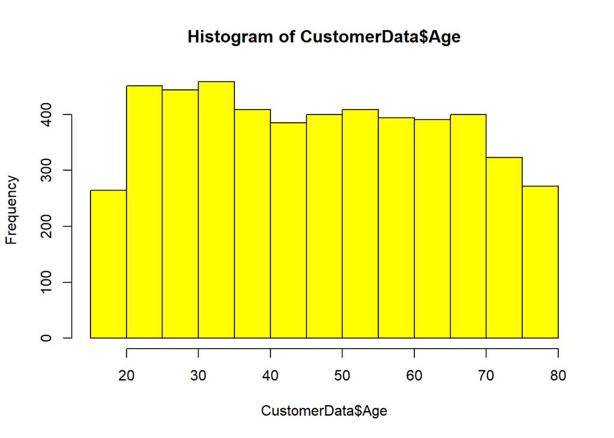

```r
hist(CustomerData$Age, col="yellow", breaks=20)
```

# 2.1.2 Histogram combined with density curve

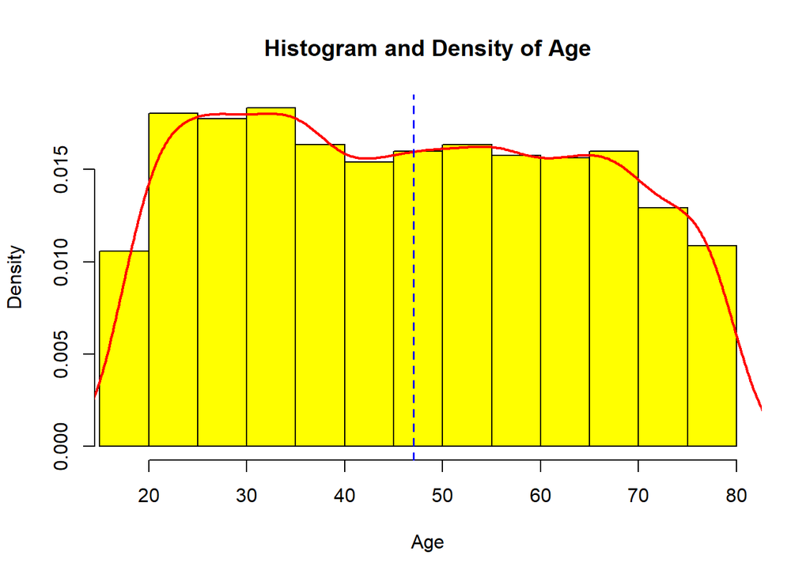

```r
hist(CustomerData$Age, prob=T, col="yellow", breaks=20, main="Histogram and Density of Age", xlim=c(min(CustomerData$Age)-1,max(CustomerData$Age)+1), xlab="Age")
lines(density(CustomerData$Age), col="red", lwd=2)

# Add a vertical line that indicates the average of Sepal Length
abline(v=mean(CustomerData$Age), col="blue", lty=2, lwd=1.5)
```

*You can change the color of the histogram, the density curve and the verticle line* *In addition to that, you can set the range of your x-axis by varying values in xlim* *Further, you can use median or other aggregations to plot the verticle line*

## 2.1.3 Plotting multiple bar charts

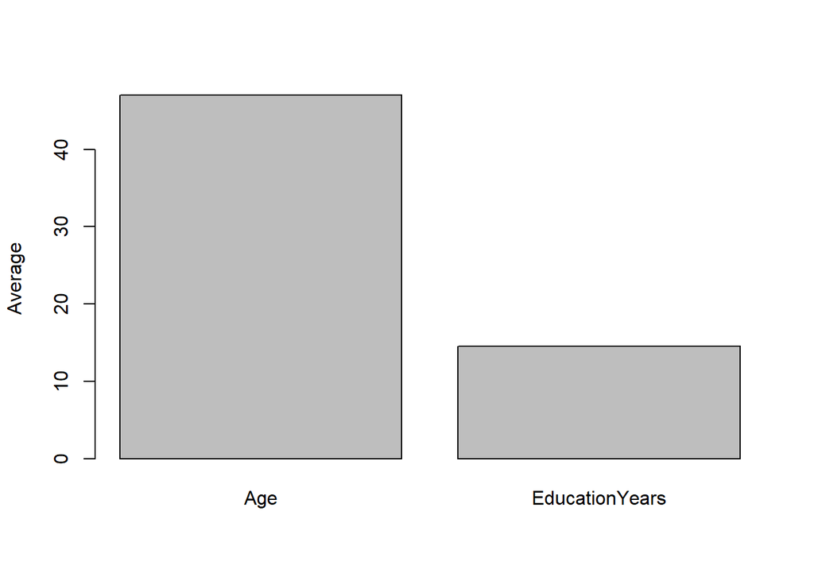

```r
avg<- apply(CustomerData[,c(5,6)], 2, mean)
barplot(avg, ylab = "Average")
```

## 2.1.4 Plotting multiple bar charts for same variable split by another variable

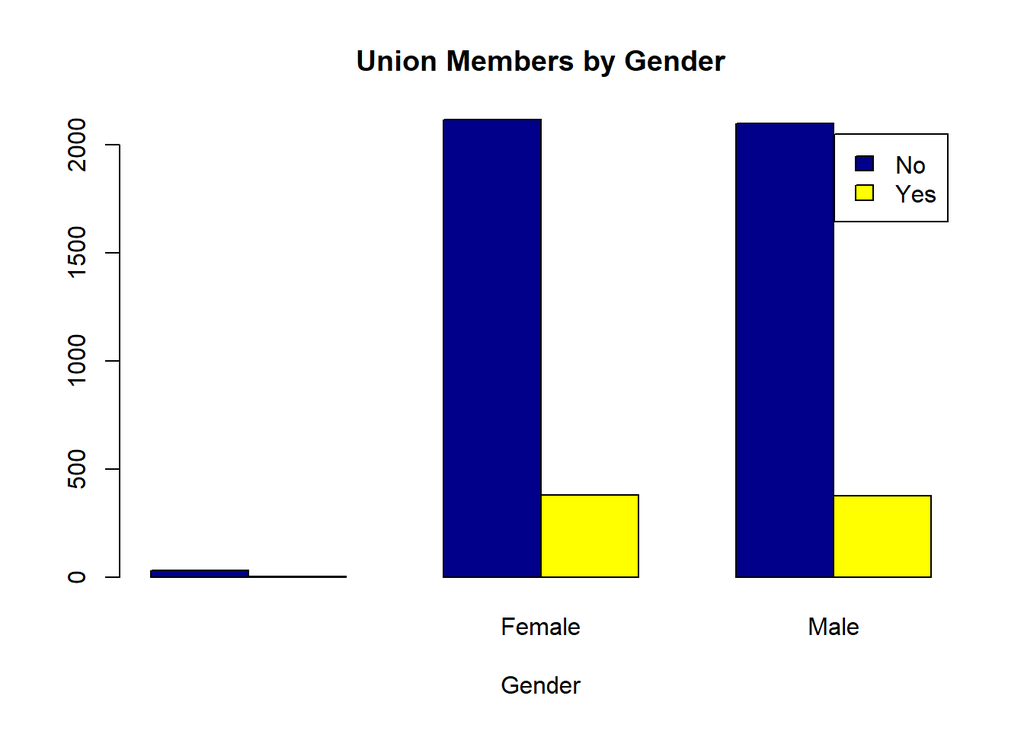

```r
counts <- table(CustomerData$UnionMember,CustomerData$Gender)
barplot(counts, main="Union Members by Gender",
  xlab="Gender", col=c("darkblue","yellow"),
  legend = rownames(counts), beside=TRUE)
```

## 2.2 Finding the outliers

# 2.2.1 Single box plot

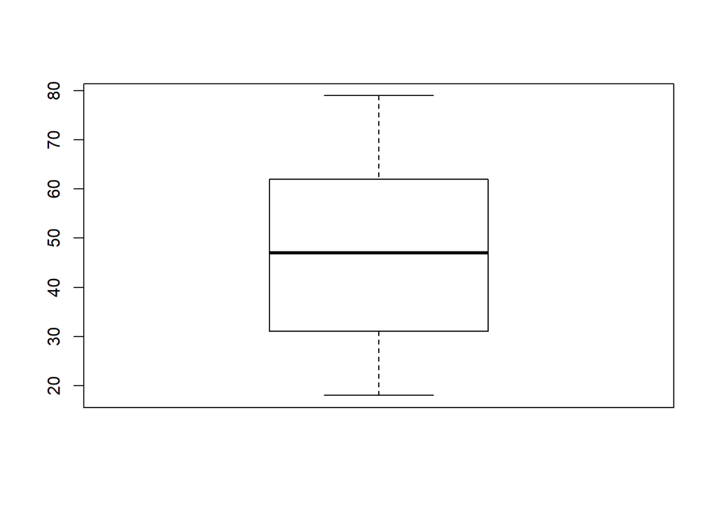

```r
boxplot(CustomerData$Age)
```

*The center line represents the median and the two ends of the box represent the 25th and 75th percentiles or 1st and 3rd Quantile* *The outer lines represent 1.5 x IQR (Inter Quantile Range is the width of the box)*

## 2.2.2 Plotting multiple box plots in same graph

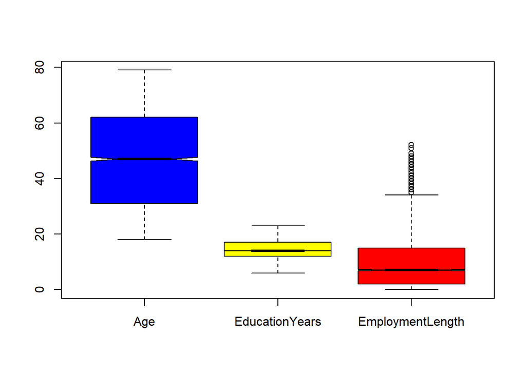

```r
boxplot(CustomerData[,c(5,6,9)], notch=T, col=c("blue", "yellow","red"))
```

## 2.2.3 Box plot of single variable with groups

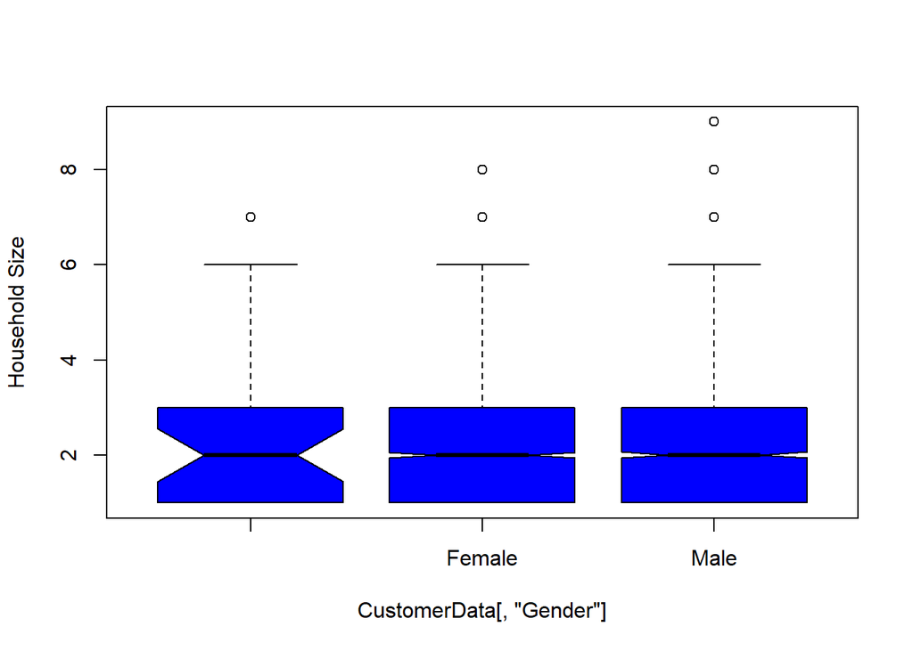

```r
boxplot(CustomerData[,'HouseholdSize']~CustomerData[,'Gender'], notch=T, ylab="Household Size", col="blue")
```

## 2.3.1 Scatter plot to observe the relation between two variables

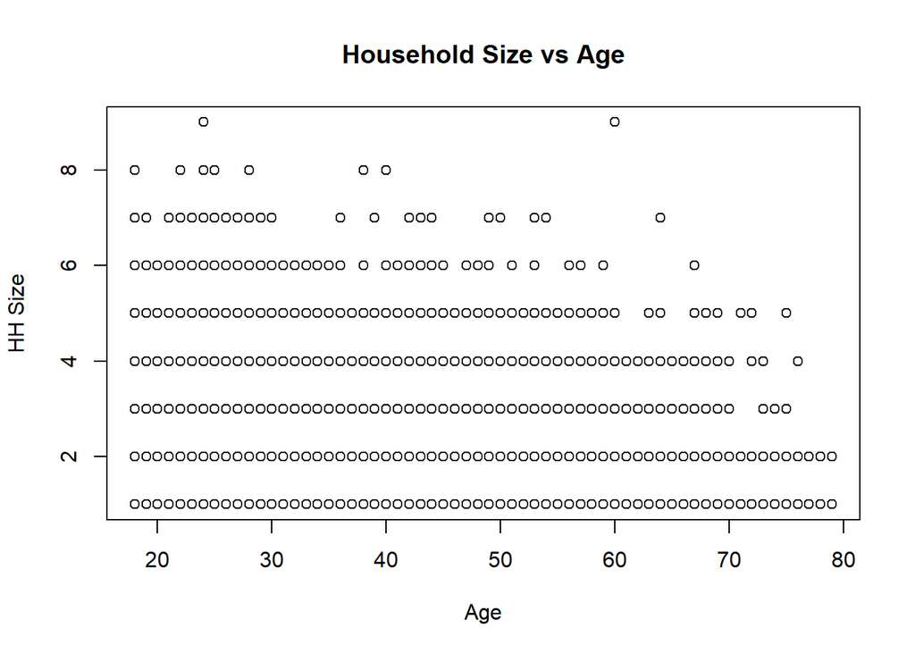

```r
plot(CustomerData$Age, CustomerData$HouseholdSize, xlab = "Age", ylab = "HH Size", main = "Household Size vs Age")
```

## 2.3.2 Scatter plot of multiple variables

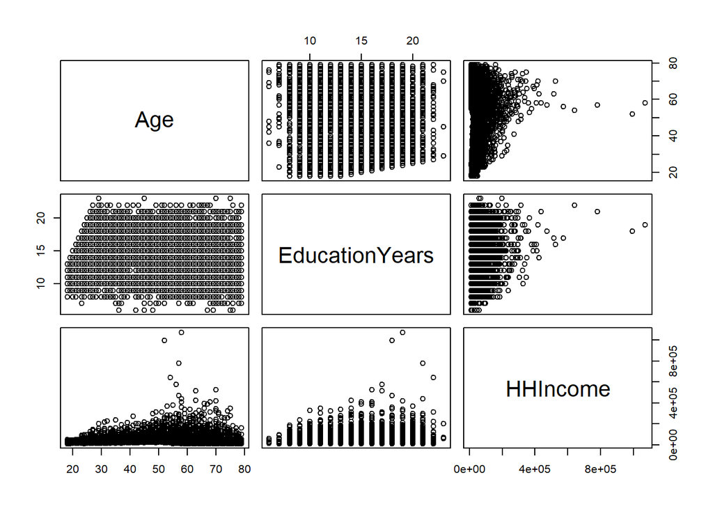

```r
pairs(CustomerData[,c(5,6,11)])
```

## 2.4 Plotting multiple graphs in same window

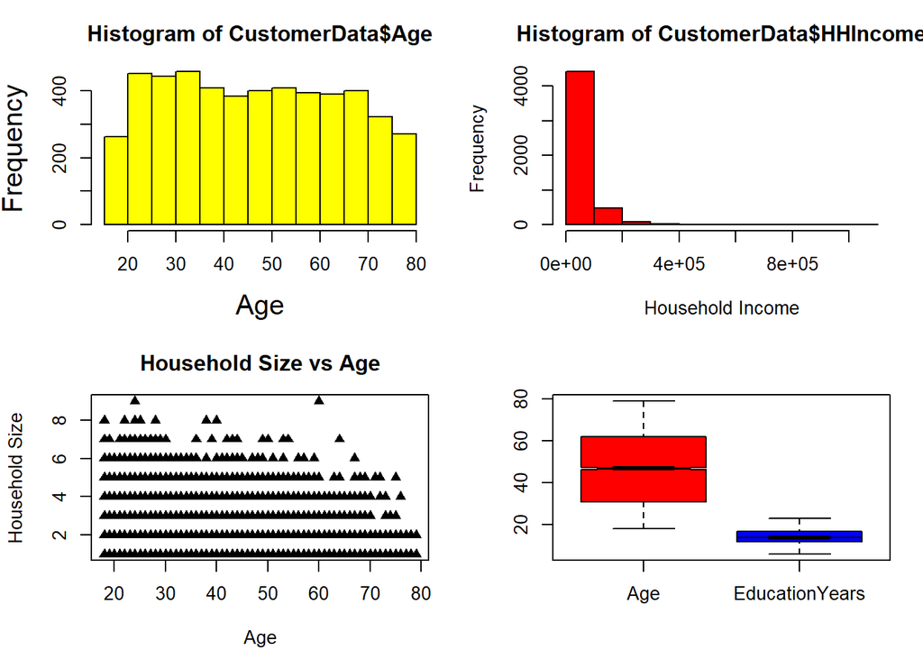

```r
# set arrangement of multiple plots. 2,2 will allow us to plot 4 graphs in a window
par(mfrow=c(2,2))
# set mrgins
par(mar=c(4.5, 4.2, 3, 1.5))

#Graph1
hist(CustomerData$Age, xlab = "Age", cex.lab=1.5, col = "yellow")

#Graph2
hist(CustomerData$HHIncome, xlab = "Household Income", col = "red")

#Graph3 (pch allows us to change shapes)
plot(CustomerData$Age, CustomerData$HouseholdSize, xlab = "Age", ylab = "Household Size", main= "Household Size vs Age", pch=17)

#Graph4
boxplot(CustomerData[,c(5,6)], notch=T, col=c("red", "blue"))
```

### 3. Using Tidyverse for exploratory data analysis

### 3.1 Filtering data

# 3.1.1 Method 1 : Using subset() function

```r
subset(x = CustomerData, subset = Age > 25 & HHIncome > 400000)
```

|  | CustomerID | Region | TownSize | Gender | Age | EducationYears | JobCategory | UnionMember | EmploymentLength | Retired | HHIncome | DebtToIncomeRatio | CreditDebt | OtherDebt | LoanDefault | MaritalStatus | HouseholdSize | NumberPets | NumberCats | NumberDogs | NumberBirds | HomeOwner | CarsOwned | CarOwnership | CarBrand | CarValue | CommuteTime | PoliticalPartyMem | Votes | … |
| --- | --- | --- | --- | --- | --- | --- | --- | --- | --- | --- | --- | --- | --- | --- | --- | --- | --- | --- | --- | --- | --- | --- | --- | --- | --- | --- | --- | --- | --- | --- |
| 18 | 0649-TBFJFL-QU4 | 5 | 2 | Male | 63 | 14 | Labor | Yes | 29 | No | 424000 | 10.7 | 13.111352 | 32.256648 | No | Married | 2 | 0 | 0 | 0 | 0 | 1 | 3 | Own | Domestic | 88600 | 29 | No | Yes | … |
| 755 | 5071-YMPEFZ-4BK | 3 | 5 | Male | 63 | 17 | Agriculture | No | 29 | No | 515000 | 3.9 | 2.289690 | 17.795310 | No | Married | 2 | 9 | 0 | 0 | 0 | 1 | 2 | Own | Foreign | 88500 | 20 | No | No | … |
| 990 | 8162-PHLLNH-12V | 5 | 1 | Female | 68 | 15 | Labor | Yes | 31 | No | 411000 | 8.3 | 10.506804 | 23.606196 | No | Married | 2 | 2 | 2 | 0 | 0 | 1 | 2 | Own | Foreign | 91300 | 13 | Yes | No | … |
| 1103 | 8402-SILWTV-4YR | 4 | 4 | Male | 58 | 19 | Service | No | 20 | No | 1073000 | 19.7 | 109.072596 | 102.308404 | Yes | Married | 2 | 8 | 0 | 2 | 0 | 1 | 4 | Own | Domestic | 77600 | 32 | Yes | Yes | … |
| 2062 | 8607-AMZELA-S5B | 5 | 1 | Female | 57 | 18 | Agriculture | No | 23 | No | 472000 | 1.2 | 1.376352 | 4.287648 | No | Unmarried | 1 | 0 | 0 | 0 | 0 | 1 | 2 | Own | Domestic | 88000 | 19 | Yes | No | … |
| 2080 | 6879-SZBXXQ-ERC | 4 | 4 | Female | 58 | 16 | Service | No | 20 | No | 409000 | 6.7 | 6.987765 | 20.415235 | No | Unmarried | 4 | 4 | 1 | 2 | 1 | 1 | 1 | Own | Foreign | 93200 | 24 | Yes | Yes | … |
| 2193 | 2329-EIXEIO-VD3 | 5 | 5 | Male | 52 | 18 | Labor | No | 24 | No | 995000 | 21.0 | 67.490850 | 141.459150 | Yes | Unmarried | 1 | 1 | 0 | 1 | 0 | 1 | 3 | Own | Domestic | 99600 | 31 | No | Yes | … |
| 2347 | 2435-DERRXC-V3A | 5 | 1 | Female | 70 | 19 | Labor | No | 37 | No | 418000 | 13.9 | 14.351194 | 43.750806 | Yes | Unmarried | 1 | 0 | 0 | 0 | 0 | 1 | 2 | Own | Foreign | 97300 | 25 | Yes | Yes | … |
| 3069 | 9069-XTCDOO-RZV | 4 | 3 | Male | 57 | 21 | Sales | No | 11 | No | 780000 | 13.1 | 35.252100 | 66.927900 | Yes | Married | 2 | 0 | 0 | 0 | 0 | 1 | 2 | Own | Foreign | 93100 | 35 | No | Yes | … |
| 3213 | 6308-REILUL-K6N | 3 | 1 | Male | 54 | 22 | Professional | No | 11 | No | 642000 | 4.6 | 11.251692 | 18.280308 | No | Married | 2 | 2 | 0 | 2 | 0 | 1 | 1 | Own | Foreign | 86300 | 25 | No | Yes | … |

[output cut: 3 more lines]

```r
# OR

subset(CustomerData, Age > 25 & HHIncome > 400000)
```

|  | CustomerID | Region | TownSize | Gender | Age | EducationYears | JobCategory | UnionMember | EmploymentLength | Retired | HHIncome | DebtToIncomeRatio | CreditDebt | OtherDebt | LoanDefault | MaritalStatus | HouseholdSize | NumberPets | NumberCats | NumberDogs | NumberBirds | HomeOwner | CarsOwned | CarOwnership | CarBrand | CarValue | CommuteTime | PoliticalPartyMem | Votes | … |
| --- | --- | --- | --- | --- | --- | --- | --- | --- | --- | --- | --- | --- | --- | --- | --- | --- | --- | --- | --- | --- | --- | --- | --- | --- | --- | --- | --- | --- | --- | --- |
| 18 | 0649-TBFJFL-QU4 | 5 | 2 | Male | 63 | 14 | Labor | Yes | 29 | No | 424000 | 10.7 | 13.111352 | 32.256648 | No | Married | 2 | 0 | 0 | 0 | 0 | 1 | 3 | Own | Domestic | 88600 | 29 | No | Yes | … |
| 755 | 5071-YMPEFZ-4BK | 3 | 5 | Male | 63 | 17 | Agriculture | No | 29 | No | 515000 | 3.9 | 2.289690 | 17.795310 | No | Married | 2 | 9 | 0 | 0 | 0 | 1 | 2 | Own | Foreign | 88500 | 20 | No | No | … |
| 990 | 8162-PHLLNH-12V | 5 | 1 | Female | 68 | 15 | Labor | Yes | 31 | No | 411000 | 8.3 | 10.506804 | 23.606196 | No | Married | 2 | 2 | 2 | 0 | 0 | 1 | 2 | Own | Foreign | 91300 | 13 | Yes | No | … |
| 1103 | 8402-SILWTV-4YR | 4 | 4 | Male | 58 | 19 | Service | No | 20 | No | 1073000 | 19.7 | 109.072596 | 102.308404 | Yes | Married | 2 | 8 | 0 | 2 | 0 | 1 | 4 | Own | Domestic | 77600 | 32 | Yes | Yes | … |
| 2062 | 8607-AMZELA-S5B | 5 | 1 | Female | 57 | 18 | Agriculture | No | 23 | No | 472000 | 1.2 | 1.376352 | 4.287648 | No | Unmarried | 1 | 0 | 0 | 0 | 0 | 1 | 2 | Own | Domestic | 88000 | 19 | Yes | No | … |
| 2080 | 6879-SZBXXQ-ERC | 4 | 4 | Female | 58 | 16 | Service | No | 20 | No | 409000 | 6.7 | 6.987765 | 20.415235 | No | Unmarried | 4 | 4 | 1 | 2 | 1 | 1 | 1 | Own | Foreign | 93200 | 24 | Yes | Yes | … |
| 2193 | 2329-EIXEIO-VD3 | 5 | 5 | Male | 52 | 18 | Labor | No | 24 | No | 995000 | 21.0 | 67.490850 | 141.459150 | Yes | Unmarried | 1 | 1 | 0 | 1 | 0 | 1 | 3 | Own | Domestic | 99600 | 31 | No | Yes | … |
| 2347 | 2435-DERRXC-V3A | 5 | 1 | Female | 70 | 19 | Labor | No | 37 | No | 418000 | 13.9 | 14.351194 | 43.750806 | Yes | Unmarried | 1 | 0 | 0 | 0 | 0 | 1 | 2 | Own | Foreign | 97300 | 25 | Yes | Yes | … |
| 3069 | 9069-XTCDOO-RZV | 4 | 3 | Male | 57 | 21 | Sales | No | 11 | No | 780000 | 13.1 | 35.252100 | 66.927900 | Yes | Married | 2 | 0 | 0 | 0 | 0 | 1 | 2 | Own | Foreign | 93100 | 35 | No | Yes | … |
| 3213 | 6308-REILUL-K6N | 3 | 1 | Male | 54 | 22 | Professional | No | 11 | No | 642000 | 4.6 | 11.251692 | 18.280308 | No | Married | 2 | 2 | 0 | 2 | 0 | 1 | 1 | Own | Foreign | 86300 | 25 | No | Yes | … |

[output cut: 3 more lines]

```r
# OR

CustomerData[(CustomerData$Age > 25 & CustomerData$HHIncome > 400000), ]
```

|  | CustomerID | Region | TownSize | Gender | Age | EducationYears | JobCategory | UnionMember | EmploymentLength | Retired | HHIncome | DebtToIncomeRatio | CreditDebt | OtherDebt | LoanDefault | MaritalStatus | HouseholdSize | NumberPets | NumberCats | NumberDogs | NumberBirds | HomeOwner | CarsOwned | CarOwnership | CarBrand | CarValue | CommuteTime | PoliticalPartyMem | Votes | … |
| --- | --- | --- | --- | --- | --- | --- | --- | --- | --- | --- | --- | --- | --- | --- | --- | --- | --- | --- | --- | --- | --- | --- | --- | --- | --- | --- | --- | --- | --- | --- |
| 18 | 0649-TBFJFL-QU4 | 5 | 2 | Male | 63 | 14 | Labor | Yes | 29 | No | 424000 | 10.7 | 13.111352 | 32.256648 | No | Married | 2 | 0 | 0 | 0 | 0 | 1 | 3 | Own | Domestic | 88600 | 29 | No | Yes | … |
| 755 | 5071-YMPEFZ-4BK | 3 | 5 | Male | 63 | 17 | Agriculture | No | 29 | No | 515000 | 3.9 | 2.289690 | 17.795310 | No | Married | 2 | 9 | 0 | 0 | 0 | 1 | 2 | Own | Foreign | 88500 | 20 | No | No | … |
| 990 | 8162-PHLLNH-12V | 5 | 1 | Female | 68 | 15 | Labor | Yes | 31 | No | 411000 | 8.3 | 10.506804 | 23.606196 | No | Married | 2 | 2 | 2 | 0 | 0 | 1 | 2 | Own | Foreign | 91300 | 13 | Yes | No | … |
| 1103 | 8402-SILWTV-4YR | 4 | 4 | Male | 58 | 19 | Service | No | 20 | No | 1073000 | 19.7 | 109.072596 | 102.308404 | Yes | Married | 2 | 8 | 0 | 2 | 0 | 1 | 4 | Own | Domestic | 77600 | 32 | Yes | Yes | … |
| 2062 | 8607-AMZELA-S5B | 5 | 1 | Female | 57 | 18 | Agriculture | No | 23 | No | 472000 | 1.2 | 1.376352 | 4.287648 | No | Unmarried | 1 | 0 | 0 | 0 | 0 | 1 | 2 | Own | Domestic | 88000 | 19 | Yes | No | … |
| 2080 | 6879-SZBXXQ-ERC | 4 | 4 | Female | 58 | 16 | Service | No | 20 | No | 409000 | 6.7 | 6.987765 | 20.415235 | No | Unmarried | 4 | 4 | 1 | 2 | 1 | 1 | 1 | Own | Foreign | 93200 | 24 | Yes | Yes | … |
| 2193 | 2329-EIXEIO-VD3 | 5 | 5 | Male | 52 | 18 | Labor | No | 24 | No | 995000 | 21.0 | 67.490850 | 141.459150 | Yes | Unmarried | 1 | 1 | 0 | 1 | 0 | 1 | 3 | Own | Domestic | 99600 | 31 | No | Yes | … |
| 2347 | 2435-DERRXC-V3A | 5 | 1 | Female | 70 | 19 | Labor | No | 37 | No | 418000 | 13.9 | 14.351194 | 43.750806 | Yes | Unmarried | 1 | 0 | 0 | 0 | 0 | 1 | 2 | Own | Foreign | 97300 | 25 | Yes | Yes | … |
| 3069 | 9069-XTCDOO-RZV | 4 | 3 | Male | 57 | 21 | Sales | No | 11 | No | 780000 | 13.1 | 35.252100 | 66.927900 | Yes | Married | 2 | 0 | 0 | 0 | 0 | 1 | 2 | Own | Foreign | 93100 | 35 | No | Yes | … |
| 3213 | 6308-REILUL-K6N | 3 | 1 | Male | 54 | 22 | Professional | No | 11 | No | 642000 | 4.6 | 11.251692 | 18.280308 | No | Married | 2 | 2 | 0 | 2 | 0 | 1 | 1 | Own | Foreign | 86300 | 25 | No | Yes | … |

[output cut: 3 more lines]

# 3.1.2 Method 2 : Using SQL to filter data

```r
sqldf('select * from CustomerData where `Age` > 25 and `HHIncome` > 400000')
```

| CustomerID | Region | TownSize | Gender | Age | EducationYears | JobCategory | UnionMember | EmploymentLength | Retired | HHIncome | DebtToIncomeRatio | CreditDebt | OtherDebt | LoanDefault | MaritalStatus | HouseholdSize | NumberPets | NumberCats | NumberDogs | NumberBirds | HomeOwner | CarsOwned | CarOwnership | CarBrand | CarValue | CommuteTime | PoliticalPartyMem | Votes | CreditCard | … |
| --- | --- | --- | --- | --- | --- | --- | --- | --- | --- | --- | --- | --- | --- | --- | --- | --- | --- | --- | --- | --- | --- | --- | --- | --- | --- | --- | --- | --- | --- | --- |
| 0649-TBFJFL-QU4 | 5 | 2 | Male | 63 | 14 | Labor | Yes | 29 | No | 424000 | 10.7 | 13.111352 | 32.256648 | No | Married | 2 | 0 | 0 | 0 | 0 | 1 | 3 | Own | Domestic | 88600 | 29 | No | Yes | Mast | … |
| 5071-YMPEFZ-4BK | 3 | 5 | Male | 63 | 17 | Agriculture | No | 29 | No | 515000 | 3.9 | 2.289690 | 17.795310 | No | Married | 2 | 9 | 0 | 0 | 0 | 1 | 2 | Own | Foreign | 88500 | 20 | No | No | Disc | … |
| 8162-PHLLNH-12V | 5 | 1 | Female | 68 | 15 | Labor | Yes | 31 | No | 411000 | 8.3 | 10.506804 | 23.606196 | No | Married | 2 | 2 | 2 | 0 | 0 | 1 | 2 | Own | Foreign | 91300 | 13 | Yes | No | Visa | … |
| 8402-SILWTV-4YR | 4 | 4 | Male | 58 | 19 | Service | No | 20 | No | 1073000 | 19.7 | 109.072596 | 102.308404 | Yes | Married | 2 | 8 | 0 | 2 | 0 | 1 | 4 | Own | Domestic | 77600 | 32 | Yes | Yes | Disc | … |
| 8607-AMZELA-S5B | 5 | 1 | Female | 57 | 18 | Agriculture | No | 23 | No | 472000 | 1.2 | 1.376352 | 4.287648 | No | Unmarried | 1 | 0 | 0 | 0 | 0 | 1 | 2 | Own | Domestic | 88000 | 19 | Yes | No | Disc | … |
| 6879-SZBXXQ-ERC | 4 | 4 | Female | 58 | 16 | Service | No | 20 | No | 409000 | 6.7 | 6.987765 | 20.415235 | No | Unmarried | 4 | 4 | 1 | 2 | 1 | 1 | 1 | Own | Foreign | 93200 | 24 | Yes | Yes | Mast | … |
| 2329-EIXEIO-VD3 | 5 | 5 | Male | 52 | 18 | Labor | No | 24 | No | 995000 | 21.0 | 67.490850 | 141.459150 | Yes | Unmarried | 1 | 1 | 0 | 1 | 0 | 1 | 3 | Own | Domestic | 99600 | 31 | No | Yes | AMEX | … |
| 2435-DERRXC-V3A | 5 | 1 | Female | 70 | 19 | Labor | No | 37 | No | 418000 | 13.9 | 14.351194 | 43.750806 | Yes | Unmarried | 1 | 0 | 0 | 0 | 0 | 1 | 2 | Own | Foreign | 97300 | 25 | Yes | Yes | Disc | … |
| 9069-XTCDOO-RZV | 4 | 3 | Male | 57 | 21 | Sales | No | 11 | No | 780000 | 13.1 | 35.252100 | 66.927900 | Yes | Married | 2 | 0 | 0 | 0 | 0 | 1 | 2 | Own | Foreign | 93100 | 35 | No | Yes | Disc | … |
| 6308-REILUL-K6N | 3 | 1 | Male | 54 | 22 | Professional | No | 11 | No | 642000 | 4.6 | 11.251692 | 18.280308 | No | Married | 2 | 2 | 0 | 2 | 0 | 1 | 1 | Own | Foreign | 86300 | 25 | No | Yes | Disc | … |

[output cut: 3 more lines]

# 3.1.3 Method 3 : Using filter() function

```r
CustomerData1 <- filter(CustomerData, Age>25 & HHIncome>400000)
CustomerData2 <- filter(CustomerData1, Gender=="Female", EducationYears<=20 | UnionMember=="Yes")
```

### 3.2.1 Random subsetting of data

```r
# Randomly sampling 90% data
CustomerDataSample1 <- CustomerData[sample(x = nrow(CustomerData), size = nrow(CustomerData)*0.90),]

# OR

CustomerDataSample2 <- sample_frac(CustomerData, 0.9)

# To sample fixed number of rows
CustomerDataSample3 <- sample_n(CustomerData, 1000)
```

# 3.2.2 Randomly splitting data into two groups

```r
index <- sample(nrow(CustomerData),nrow(CustomerData)*0.90)
CustomerData.train = CustomerData[index,]
CustomerData.test = CustomerData[-index,]
```

### 3.3 Sorting data

*Here we are extracting the first 5 rows. This can be modified based on the requirements*

```r
CustomerData[order(CustomerData$Age, decreasing = TRUE)[1:5], ]
```

|  | CustomerID | Region | TownSize | Gender | Age | EducationYears | JobCategory | UnionMember | EmploymentLength | Retired | HHIncome | DebtToIncomeRatio | CreditDebt | OtherDebt | LoanDefault | MaritalStatus | HouseholdSize | NumberPets | NumberCats | NumberDogs | NumberBirds | HomeOwner | CarsOwned | CarOwnership | CarBrand | CarValue | CommuteTime | PoliticalPartyMem | Votes | … |
| --- | --- | --- | --- | --- | --- | --- | --- | --- | --- | --- | --- | --- | --- | --- | --- | --- | --- | --- | --- | --- | --- | --- | --- | --- | --- | --- | --- | --- | --- | --- |
| 172 | 8214-NVCQAC-3HH | 2 | 2 | Male | 79 | 12 | Crafts | No | 39 | Yes | 47000 | 7.9 | 1.095335 | 2.617665 | No | Married | 2 | 0 | 0 | 0 | 0 | 1 | 1 | Lease | Foreign | 19300 | 26 | No | No | … |
| 176 | 8931-XMXDFT-RXL | 1 | 1 | Female | 79 | 7 | Agriculture | No | 45 | Yes | 20000 | 19.2 | 1.409280 | 2.430720 | No | Unmarried | 1 | 2 | 0 | 0 | 0 | 1 | 1 | Lease | Foreign | 10000 | 22 | No | Yes | … |
| 185 | 1734-EAYBEZ-PZ0 | 2 | 1 | Male | 79 | 16 | Professional | No | 15 | Yes | 26000 | 18.1 | 2.301234 | 2.404766 | No | Unmarried | 1 | 0 | 0 | 0 | 0 | 0 | 4 | Lease | Domestic | 11500 | 21 | Yes | No | … |
| 227 | 4092-XAPMSL-F1S | 1 | 1 | Female | 79 | 12 | Professional | No | 13 | Yes | 10000 | 6.8 | 0.060520 | 0.619480 | No | Married | 2 | 4 | 3 | 1 | 0 | 0 | 1 | Own | Foreign | 4200 | 27 | Yes | No | … |
| 312 | 2175-VGCTPF-370 | 4 | 4 | Male | 79 | 12 | Sales | No | 6 | Yes | 9000 | 3.8 | 0.166896 | 0.175104 | No | Married | 2 | 1 | 0 | 1 | 0 | 0 | 3 | Lease | Domestic | 3800 | 27 | Yes | Yes | … |

```r
# OR

arrange(CustomerData, desc(Age))[1:5, ] #Descending
```

|  | CustomerID | Region | TownSize | Gender | Age | EducationYears | JobCategory | UnionMember | EmploymentLength | Retired | HHIncome | DebtToIncomeRatio | CreditDebt | OtherDebt | LoanDefault | MaritalStatus | HouseholdSize | NumberPets | NumberCats | NumberDogs | NumberBirds | HomeOwner | CarsOwned | CarOwnership | CarBrand | CarValue | CommuteTime | PoliticalPartyMem | Votes | … |
| --- | --- | --- | --- | --- | --- | --- | --- | --- | --- | --- | --- | --- | --- | --- | --- | --- | --- | --- | --- | --- | --- | --- | --- | --- | --- | --- | --- | --- | --- | --- |
| 1 | 8214-NVCQAC-3HH | 2 | 2 | Male | 79 | 12 | Crafts | No | 39 | Yes | 47000 | 7.9 | 1.095335 | 2.617665 | No | Married | 2 | 0 | 0 | 0 | 0 | 1 | 1 | Lease | Foreign | 19300 | 26 | No | No | … |
| 2 | 8931-XMXDFT-RXL | 1 | 1 | Female | 79 | 7 | Agriculture | No | 45 | Yes | 20000 | 19.2 | 1.409280 | 2.430720 | No | Unmarried | 1 | 2 | 0 | 0 | 0 | 1 | 1 | Lease | Foreign | 10000 | 22 | No | Yes | … |
| 3 | 1734-EAYBEZ-PZ0 | 2 | 1 | Male | 79 | 16 | Professional | No | 15 | Yes | 26000 | 18.1 | 2.301234 | 2.404766 | No | Unmarried | 1 | 0 | 0 | 0 | 0 | 0 | 4 | Lease | Domestic | 11500 | 21 | Yes | No | … |
| 4 | 4092-XAPMSL-F1S | 1 | 1 | Female | 79 | 12 | Professional | No | 13 | Yes | 10000 | 6.8 | 0.060520 | 0.619480 | No | Married | 2 | 4 | 3 | 1 | 0 | 0 | 1 | Own | Foreign | 4200 | 27 | Yes | No | … |
| 5 | 2175-VGCTPF-370 | 4 | 4 | Male | 79 | 12 | Sales | No | 6 | Yes | 9000 | 3.8 | 0.166896 | 0.175104 | No | Married | 2 | 1 | 0 | 1 | 0 | 0 | 3 | Lease | Domestic | 3800 | 27 | Yes | Yes | … |

```r
# OR

arrange(CustomerData, Age)[1:5, ] #Ascending
```

|  | CustomerID | Region | TownSize | Gender | Age | EducationYears | JobCategory | UnionMember | EmploymentLength | Retired | HHIncome | DebtToIncomeRatio | CreditDebt | OtherDebt | LoanDefault | MaritalStatus | HouseholdSize | NumberPets | NumberCats | NumberDogs | NumberBirds | HomeOwner | CarsOwned | CarOwnership | CarBrand | CarValue | CommuteTime | PoliticalPartyMem | Votes | … |
| --- | --- | --- | --- | --- | --- | --- | --- | --- | --- | --- | --- | --- | --- | --- | --- | --- | --- | --- | --- | --- | --- | --- | --- | --- | --- | --- | --- | --- | --- | --- |
| 1 | 9723-VUGZBJ-ZQA | 3 | 3 | Male | 18 | 13 | Service | No | 0 | No | 15000 | 10.9 | 0.516660 | 1.118340 | Yes | Unmarried | 1 | 0 | 0 | 0 | 0 | 0 | 3 | Lease | Domestic | 6100 | 30 | No | Yes | … |
| 2 | 3754-JJTSIX-HW4 | 5 | 5 | Female | 18 | 13 | Professional | No | 0 | No | 19000 | 4.1 | 0.101270 | 0.677730 | No | Married | 6 | 2 | 0 | 1 | 0 | 0 | 5 | Own | Foreign | 8700 | 24 | Yes | No | … |
| 3 | 1103-KTXUJS-ZPH | 3 | 1 | Female | 18 | 13 | Service | No | 0 | No | 15000 | 4.9 | 0.210210 | 0.524790 | No | Married | 4 | 1 | 1 | 0 | 0 | 1 | 2 | Lease | Domestic | 9100 | 17 | Yes | Yes | … |
| 4 | 2736-QDRAAN-VAI | 5 | 5 | Female | 18 | 13 | Sales | No | 0 | No | 21000 | 4.5 | 0.179550 | 0.765450 | Yes | Married | 4 | 2 | 2 | 0 | 0 | 1 | 3 | Own | Domestic | 13400 | 44 | Yes | Yes | … |
| 5 | 1163-JCDRWZ-Q3K | 4 | 2 | Male | 18 | 13 | Professional | No | 0 | No | 19000 | 22.2 | 3.766674 | 0.451326 | Yes | Married | 5 | 0 | 0 | 0 | 0 | 1 | 4 | Own | Domestic | 10600 | 25 | Yes | No | … |

```r
# Sorting using multiple columns

CustomerData_sort<- arrange(CustomerData, Age, desc(HHIncome))[1:5,]
```

### 3.4 Variable details

## 3.4.1 Extracting column names

```r
names(CustomerData)
```

```
##  [1] "CustomerID"          "Region"              "TownSize"
##  [4] "Gender"              "Age"                 "EducationYears"
##  [7] "JobCategory"         "UnionMember"         "EmploymentLength"
## [10] "Retired"             "HHIncome"            "DebtToIncomeRatio"
## [13] "CreditDebt"          "OtherDebt"           "LoanDefault"
## [16] "MaritalStatus"       "HouseholdSize"       "NumberPets"
## [19] "NumberCats"          "NumberDogs"          "NumberBirds"
## [22] "HomeOwner"           "CarsOwned"           "CarOwnership"
## [25] "CarBrand"            "CarValue"            "CommuteTime"
## [28] "PoliticalPartyMem"   "Votes"               "CreditCard"
## [31] "CardTenure"          "CardItemsMonthly"    "CardSpendMonth"
## [34] "ActiveLifestyle"     "PhoneCoTenure"       "VoiceLastMonth"
## [37] "VoiceOverTenure"     "EquipmentRental"     "EquipmentLastMonth"
## [40] "EquipmentOverTenure" "CallingCard"         "WirelessData"
## [43] "DataLastMonth"       "DataOverTenure"      "Multiline"
## [46] "VM"                  "Pager"               "Internet"
## [49] "CallerID"            "CallWait"            "CallForward"
## [52] "ThreeWayCalling"     "EBilling"            "TVWatchingHours"
## [55] "OwnsPC"              "OwnsMobileDevice"    "OwnsGameSystem"
## [58] "OwnsFax"             "NewsSubscriber"
```

# 3.4.2 Selecting columns

```r
CustomerData[, c("Age", "HHIncome")]
```

| Age | HHIncome |
| --- | --- |
| 20 | 31000 |
| 22 | 15000 |
| 67 | 35000 |
| 23 | 20000 |
| 26 | 23000 |
| 64 | 107000 |
| 52 | 77000 |
| 44 | 97000 |
| 66 | 16000 |
| 47 | 84000 |

[output cut: 4990 more lines]

```r
# OR

varname <- c("Age", "HHIncome")
CustomerData_select <- select(CustomerData, varname)

# OR

CustomerData_select <- CustomerData[,varname]
```

# 3.4.3 Dropping columns

```r
CustomerData_select2 <- select(CustomerData, -Age, -HHIncome)

# OR

varname <- c("Age", "HHIncome")
CustomerData_select2 <- CustomerData[,!names(CustomerData) %in% varname]
names(CustomerData_select2)
```

```
##  [1] "CustomerID"          "Region"              "TownSize"
##  [4] "Gender"              "EducationYears"      "JobCategory"
##  [7] "UnionMember"         "EmploymentLength"    "Retired"
## [10] "DebtToIncomeRatio"   "CreditDebt"          "OtherDebt"
## [13] "LoanDefault"         "MaritalStatus"       "HouseholdSize"
## [16] "NumberPets"          "NumberCats"          "NumberDogs"
## [19] "NumberBirds"         "HomeOwner"           "CarsOwned"
## [22] "CarOwnership"        "CarBrand"            "CarValue"
## [25] "CommuteTime"         "PoliticalPartyMem"   "Votes"
## [28] "CreditCard"          "CardTenure"          "CardItemsMonthly"
## [31] "CardSpendMonth"      "ActiveLifestyle"     "PhoneCoTenure"
## [34] "VoiceLastMonth"      "VoiceOverTenure"     "EquipmentRental"
## [37] "EquipmentLastMonth"  "EquipmentOverTenure" "CallingCard"
## [40] "WirelessData"        "DataLastMonth"       "DataOverTenure"
## [43] "Multiline"           "VM"                  "Pager"
## [46] "Internet"            "CallerID"            "CallWait"
## [49] "CallForward"         "ThreeWayCalling"     "EBilling"
## [52] "TVWatchingHours"     "OwnsPC"              "OwnsMobileDevice"
## [55] "OwnsGameSystem"      "OwnsFax"             "NewsSubscriber"
```

# 3.4.4 Reordering columns

```r
CustomerData_order2 <- select(CustomerData, Age, HHIncome, everything())

names(CustomerData_order2)
```

```
##  [1] "Age"                 "HHIncome"            "CustomerID"
##  [4] "Region"              "TownSize"            "Gender"
##  [7] "EducationYears"      "JobCategory"         "UnionMember"
## [10] "EmploymentLength"    "Retired"             "DebtToIncomeRatio"
## [13] "CreditDebt"          "OtherDebt"           "LoanDefault"
## [16] "MaritalStatus"       "HouseholdSize"       "NumberPets"
## [19] "NumberCats"          "NumberDogs"          "NumberBirds"
## [22] "HomeOwner"           "CarsOwned"           "CarOwnership"
## [25] "CarBrand"            "CarValue"            "CommuteTime"
## [28] "PoliticalPartyMem"   "Votes"               "CreditCard"
## [31] "CardTenure"          "CardItemsMonthly"    "CardSpendMonth"
## [34] "ActiveLifestyle"     "PhoneCoTenure"       "VoiceLastMonth"
## [37] "VoiceOverTenure"     "EquipmentRental"     "EquipmentLastMonth"
## [40] "EquipmentOverTenure" "CallingCard"         "WirelessData"
## [43] "DataLastMonth"       "DataOverTenure"      "Multiline"
## [46] "VM"                  "Pager"               "Internet"
## [49] "CallerID"            "CallWait"            "CallForward"
## [52] "ThreeWayCalling"     "EBilling"            "TVWatchingHours"
## [55] "OwnsPC"              "OwnsMobileDevice"    "OwnsGameSystem"
## [58] "OwnsFax"             "NewsSubscriber"
```

# 3.4.5 Renaming variables

```r
CustomerData_rename<- rename(CustomerData, Education=EducationYears, Income=HHIncome)

CustomerData_rename1<-select(CustomerData_rename, Education, Income, everything())

names(CustomerData_rename1)
```

```
##  [1] "Education"           "Income"              "CustomerID"
##  [4] "Region"              "TownSize"            "Gender"
##  [7] "Age"                 "JobCategory"         "UnionMember"
## [10] "EmploymentLength"    "Retired"             "DebtToIncomeRatio"
## [13] "CreditDebt"          "OtherDebt"           "LoanDefault"
## [16] "MaritalStatus"       "HouseholdSize"       "NumberPets"
## [19] "NumberCats"          "NumberDogs"          "NumberBirds"
## [22] "HomeOwner"           "CarsOwned"           "CarOwnership"
## [25] "CarBrand"            "CarValue"            "CommuteTime"
## [28] "PoliticalPartyMem"   "Votes"               "CreditCard"
## [31] "CardTenure"          "CardItemsMonthly"    "CardSpendMonth"
## [34] "ActiveLifestyle"     "PhoneCoTenure"       "VoiceLastMonth"
## [37] "VoiceOverTenure"     "EquipmentRental"     "EquipmentLastMonth"
## [40] "EquipmentOverTenure" "CallingCard"         "WirelessData"
## [43] "DataLastMonth"       "DataOverTenure"      "Multiline"
## [46] "VM"                  "Pager"               "Internet"
## [49] "CallerID"            "CallWait"            "CallForward"
## [52] "ThreeWayCalling"     "EBilling"            "TVWatchingHours"
## [55] "OwnsPC"              "OwnsMobileDevice"    "OwnsGameSystem"
## [58] "OwnsFax"             "NewsSubscriber"
```

# 3.4.6 Creating new variable

*There are multiple ways to create new columns. Using mutate is the simplest while other methods might require multiple steps*

```r
CustomerData_newvar<- mutate(CustomerData, Age_Income_Ratio=HHIncome/Age)
names(CustomerData_newvar)
```

```
##  [1] "CustomerID"          "Region"              "TownSize"
##  [4] "Gender"              "Age"                 "EducationYears"
##  [7] "JobCategory"         "UnionMember"         "EmploymentLength"
## [10] "Retired"             "HHIncome"            "DebtToIncomeRatio"
## [13] "CreditDebt"          "OtherDebt"           "LoanDefault"
## [16] "MaritalStatus"       "HouseholdSize"       "NumberPets"
## [19] "NumberCats"          "NumberDogs"          "NumberBirds"
## [22] "HomeOwner"           "CarsOwned"           "CarOwnership"
## [25] "CarBrand"            "CarValue"            "CommuteTime"
## [28] "PoliticalPartyMem"   "Votes"               "CreditCard"
## [31] "CardTenure"          "CardItemsMonthly"    "CardSpendMonth"
## [34] "ActiveLifestyle"     "PhoneCoTenure"       "VoiceLastMonth"
## [37] "VoiceOverTenure"     "EquipmentRental"     "EquipmentLastMonth"
## [40] "EquipmentOverTenure" "CallingCard"         "WirelessData"
## [43] "DataLastMonth"       "DataOverTenure"      "Multiline"
## [46] "VM"                  "Pager"               "Internet"
## [49] "CallerID"            "CallWait"            "CallForward"
## [52] "ThreeWayCalling"     "EBilling"            "TVWatchingHours"
## [55] "OwnsPC"              "OwnsMobileDevice"    "OwnsGameSystem"
## [58] "OwnsFax"             "NewsSubscriber"      "Age_Income_Ratio"
```

### 3.5 Missing data analysis

# 3.5.1 Getting the number of missing values in the dataset

```r
sum(is.na(CustomerData))
```

```
## [1] 76
```

# 3.5.2 Getting the missing values for each variable

```r
colSums(is.na(CustomerData))
```

```
##          CustomerID              Region            TownSize              Gender
##                   0                   0                   0                   0
##                 Age      EducationYears         JobCategory         UnionMember
##                   0                   0                   0                   0
##    EmploymentLength             Retired            HHIncome   DebtToIncomeRatio
##                   0                   0                   0                   0
##          CreditDebt           OtherDebt         LoanDefault       MaritalStatus
##                   0                   0                   0                   0
##       HouseholdSize          NumberPets          NumberCats          NumberDogs
##                   8                   6                   7                   8
##         NumberBirds           HomeOwner           CarsOwned        CarOwnership
##                  34                  13                   0                   0
##            CarBrand            CarValue         CommuteTime   PoliticalPartyMem
##                   0                   0                   0                   0
##               Votes          CreditCard          CardTenure    CardItemsMonthly
##                   0                   0                   0                   0
##      CardSpendMonth     ActiveLifestyle       PhoneCoTenure      VoiceLastMonth
##                   0                   0                   0                   0
##     VoiceOverTenure     EquipmentRental  EquipmentLastMonth EquipmentOverTenure
##                   0                   0                   0                   0
##         CallingCard        WirelessData       DataLastMonth      DataOverTenure
##                   0                   0                   0                   0
##           Multiline                  VM               Pager            Internet
##                   0                   0                   0                   0
##            CallerID            CallWait         CallForward     ThreeWayCalling
##                   0                   0                   0                   0
##            EBilling     TVWatchingHours              OwnsPC    OwnsMobileDevice
##                   0                   0                   0                   0
##      OwnsGameSystem             OwnsFax      NewsSubscriber
##                   0                   0                   0
```

# 3.5.3 Removing entries with missing values

```r
CustomerData.Clean<- na.omit(CustomerData)

sum(is.na(CustomerData.Clean))
```

```
## [1] 0
```

# 3.5.4 Removing entries with missing values for a specific variable

```r
CustomerData.Clean1<-CustomerData[!is.na(CustomerData$NumberPets),]

colSums(is.na(CustomerData.Clean1))
```

```
##          CustomerID              Region            TownSize              Gender
##                   0                   0                   0                   0
##                 Age      EducationYears         JobCategory         UnionMember
##                   0                   0                   0                   0
##    EmploymentLength             Retired            HHIncome   DebtToIncomeRatio
##                   0                   0                   0                   0
##          CreditDebt           OtherDebt         LoanDefault       MaritalStatus
##                   0                   0                   0                   0
##       HouseholdSize          NumberPets          NumberCats          NumberDogs
##                   8                   0                   7                   8
##         NumberBirds           HomeOwner           CarsOwned        CarOwnership
##                  33                  12                   0                   0
##            CarBrand            CarValue         CommuteTime   PoliticalPartyMem
##                   0                   0                   0                   0
##               Votes          CreditCard          CardTenure    CardItemsMonthly
##                   0                   0                   0                   0
##      CardSpendMonth     ActiveLifestyle       PhoneCoTenure      VoiceLastMonth
##                   0                   0                   0                   0
##     VoiceOverTenure     EquipmentRental  EquipmentLastMonth EquipmentOverTenure
##                   0                   0                   0                   0
##         CallingCard        WirelessData       DataLastMonth      DataOverTenure
##                   0                   0                   0                   0
##           Multiline                  VM               Pager            Internet
##                   0                   0                   0                   0
##            CallerID            CallWait         CallForward     ThreeWayCalling
##                   0                   0                   0                   0
##            EBilling     TVWatchingHours              OwnsPC    OwnsMobileDevice
##                   0                   0                   0                   0
##      OwnsGameSystem             OwnsFax      NewsSubscriber
##                   0                   0                   0
```